# 20240413_slides slides

### High-level Message Note 1: I can confidentally see there isn't any significant concern because it appears the values are legitimate as they all have a value of 1 in their wks_on_chart column or they re-entered charts after falling off of it.

### Question (Motivation) #1: Has anyone had a song on the charts longer than the longest Beatles' song ever on the charts?

### Method 1: First, isolate the Beatles data in their own dataframe and all other artists in a different one to compare easily. I'll also group the ROW df by performer & title in case there are any songs that released by more than one artist (covers) and then sort both dfs by wks_on_chart in descending order.

## Categorical Variables

### Two categories: The Beatles song on the charts the longest vs. the Non-Beatles song on the charts the longest.

### Mechanics 1: Create dataframes of data grouping by performer & title to determine the longest artist-song runs with max() and compare. Data visualization: also compare with bar plot.

```python
df2 = pd.read_csv('hot-100-current.csv')
max2 = df2.groupby(['performer','title'],as_index=False)['wks_on_chart'].max()
max3 = max2.sort_values(by=['wks_on_chart'], ascending=False)
print (max3)
```

```
                                    performer                 title  \
10432                           Glass Animals            Heat Waves
28565                              The Weeknd       Blinding Lights
11692                         Imagine Dragons           Radioactive
416                                AWOLNATION                  Sail
7823                                 Dua Lipa            Levitating
...                                       ...                   ...
22214                            Robin Thicke          Get Her Back
28645  The White Buffalo & The Forest Rangers  Come Join The Murder
10589                               Glee Cast        Sweet Caroline
10590                               Glee Cast            Take A Bow
9842                                   Future         Super Trapper

       wks_on_chart
10432            91
28565            90
11692            87
416              79
7823             77
...             ...
22214             1
28645             1
10589             1
10590             1
9842              1

[31052 rows x 3 columns]
```

```python
# wow so see, what's with the come together/something line? why isn't it hashed with got to get you into my life, which is also 16 weeks?
# remember to look it up online later - stay on target!
maxes2 = max3[max3['performer']=='The Beatles']
print (maxes2)
```

```
         performer                             title  wks_on_chart
25563  The Beatles                   Twist And Shout            26
25525  The Beatles                          Hey Jude            19
25514  The Beatles           Come Together/Something            16
25522  The Beatles       Got To Get You Into My Life            16
25551  The Beatles                     She Loves You            15
...            ...                               ...           ...
25565  The Beatles                      What Goes On             2
25539  The Beatles                      Now And Then             2
25561  The Beatles                   There's A Place             1
25559  The Beatles                   The Inner Light             1
25533  The Beatles  I'm Happy Just To Dance With You             1

[66 rows x 3 columns]
```

### Message 1: Wow, yes! there's been a lot of songs on the charts with runs longer than the Beatles longest running song, Twist and Shout at 26 weeks. The longest being Glass Animals with Heat Waves at a wopping 91 weeks! I was not expecting that... :(

```python
# Longest running song on the charts in weeks by an artist?
allmaxweeks = max3.iloc[0].wks_on_chart
allmaxperformer = max3.iloc[0].performer
allmaxtitle = max3.iloc[0].title
# print(allmaxweeks)
# longest running song on the charts by The Beatles
maxes2.iloc[0]
bmaxweeks = maxes2.iloc[0].wks_on_chart
#bmaxperformer = maxes2.iloc[0].performer
bmaxtitle = maxes2.iloc[0].title
```

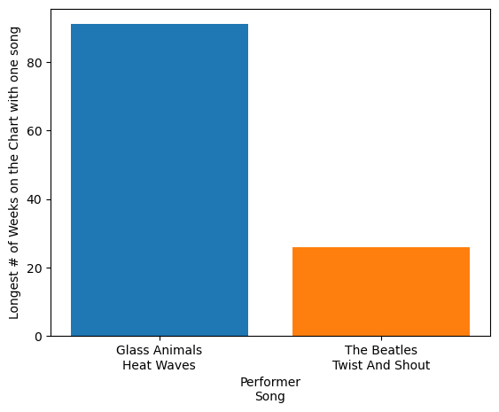

```python
import matplotlib.pyplot as plt

plt.xlabel("Performer\n"+"Song")
plt.ylabel("Longest # of Weeks on the Chart with one song")
plt.bar(allmaxperformer+"\n"+allmaxtitle, allmaxweeks)
plt.bar('The Beatles'+"\n"+bmaxtitle, bmaxweeks);
```

### Motivation 2: How many other bands have hit #1 like the Beatles? How many other songs have hit #1?

## Numerical Variables

### Method 2: To find out, do a distribution of peak position by title.

### Explanatory Data Analysis Part 2: First, I'm curious about how many number one songs are in the file.

### Mechanics 2: Review counts of all columns for # hits.

```python
df2[df2['peak_pos']==1].count()
```

```
chart_week      17762
current_week    17762
title           17762
performer       17762
last_week       17671
peak_pos        17762
wks_on_chart    17762
dtype: int64
```

### Message 2: Close, but that's just a count of RECORDS that the non-NaN values in the columns where "1" is the value in the peak_pos column, but there could be many records for the same song with a peak_pos of 1. What I do find interesting is that there appear to be some songs that debuted at #1 b/c there are some songs that have a NaN (discovered above) for the last_week column. More significance to investigate later as possible Question / Problem / Motivation.

### Motivation 3: Now I can find out how many songs that enter billboard 100 equal Beatles peak_pos #1.

### Method 3 / EDA 3: First, I'll isolate the Beatles raw data and look at the all of the numerical variables' histograms. Second, let me see the distribution of the max peak chart positions for each performer/song data record, just to see what the shape (I predict it is a long tail to the left so neg skewness since it is harder to get a #1) of distribution of peak_pos which is a histogram since it is numeric data, I can do one-hot swapping of the categoricals once I get to regression.

### Mechanics 3: Use dataframes to manipulate data and visualize into historgram distributions.

```python
df = df[df['performer'] == 'The Beatles']
print (df)
```

```
        chart_week  current_week                     title    performer  \
9806    2023-11-18             7              Now And Then  The Beatles
9975    2023-11-25            76              Now And Then  The Beatles
39144   1964-01-18            45  I Want To Hold Your Hand  The Beatles
39202   1964-01-25             3  I Want To Hold Your Hand  The Beatles
39268   1964-01-25            69             She Loves You  The Beatles
...            ...           ...                       ...          ...
339458  1976-12-04            59        Ob-la-di, Ob-la-da  The Beatles
339548  1976-12-11            49        Ob-la-di, Ob-la-da  The Beatles
339648  1976-12-18            49        Ob-la-di, Ob-la-da  The Beatles
339770  1976-12-25            71        Ob-la-di, Ob-la-da  The Beatles
339870  1977-01-01            71        Ob-la-di, Ob-la-da  The Beatles

        last_week  peak_pos  wks_on_chart
9806          0.0         7             1
9975          7.0         7             2
39144         NaN        45             1
39202        45.0         3             2
39268         NaN        69             1
...           ...       ...           ...
339458       69.0        59             3
339548       59.0        49             4
339648       49.0        49             5
339770       49.0        49             6
339870       71.0        49             7

[587 rows x 7 columns]
```

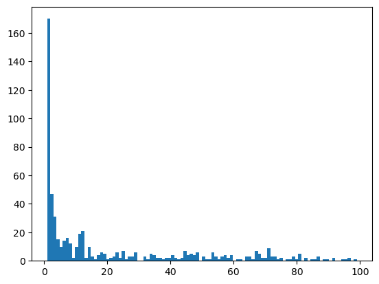

```python
plt.hist(x='peak_pos', bins=100, data=df);
```

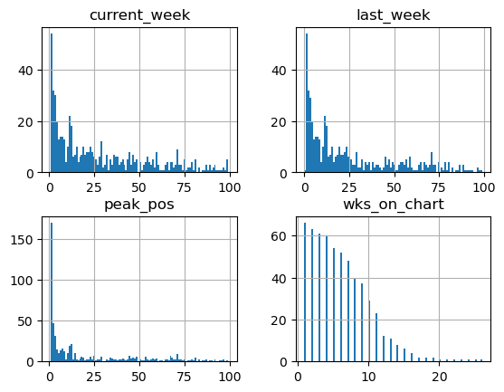

```python
df.hist(bins=100);
```

```python
max_wks_peak_all = df2.groupby(['performer', 'title'], as_index=False).agg({'wks_on_chart': 'max', 'peak_pos': 'max'})
max_wks_peak_all
```

|  | performer | title | wks_on_chart | peak_pos |
| --- | --- | --- | --- | --- |
| 0 | "Groove" Holmes | Misty | 11 | 100 |
| 1 | "Groove" Holmes | What Now My Love | 3 | 98 |
| 2 | "Little" Jimmy Dickens | May The Bird Of Paradise Fly Up Your Nose | 10 | 90 |
| 3 | "Pookie" Hudson | I Know I Know | 1 | 96 |
| 4 | "Weird Al" Yankovic | Amish Paradise | 16 | 65 |
| ... | ... | ... | ... | ... |
| 31047 | will.i.am & Nicki Minaj | Check It Out | 15 | 78 |
| 31048 | will.i.am Featuring Justin Bieber | #thatPOWER | 16 | 42 |
| 31049 | will.i.am Featuring Mick Jagger & Jennifer Lopez | T.H.E (The Hardest Ever) | 8 | 36 |
| 31050 | will.i.am Featuring Miley Cyrus | Fall Down | 1 | 58 |
| 31051 | will.i.am Featuring Miley Cyrus, French Montan... | Feelin' Myself | 2 | 96 |

31052 rows × 4 columns

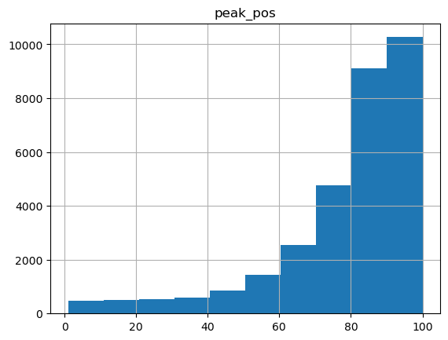

```python
max_wks_peak_all.hist('peak_pos');
```

### Message 3b: Yep, it looks like i thought it would. Most artists only peak in the higher values for peak_pos where 1 is the highest rank and 100 the lowest.

### Motivation 4: What is the average peak_pos and average wks_on_chart for entire file (all title/band combos)?

### Method 4: EDA & Take the means of the above columns

### Mechanics 4: Use dataframe function(s)

```python
max_wks_peak_all.describe()
```

|  | wks_on_chart | peak_pos |
| --- | --- | --- |
| count | 31052.000000 | 31052.000000 |
| mean | 11.011883 | 79.201984 |
| std | 8.514665 | 20.461379 |
| min | 1.000000 | 1.000000 |
| 25% | 4.000000 | 73.000000 |
| 50% | 9.000000 | 85.000000 |
| 75% | 16.000000 | 93.000000 |
| max | 91.000000 | 100.000000 |

```python
#so the average peak position of a band/title combo on the charts is
max_peak_pos_mean = max_wks_peak_all.agg(x=('peak_pos','mean'))
```

### Message 4: Average peak for all songs is only 79 -- what is the beatles highest average peak position I wonder? A question for later.

### Motivation 5: But first, let's say a record company is trying to determine which artists to rehire so they decide to only re-sign artists to a contract if they chart better than the average billboard 100 artist with a song.

### Method 5 Part I: So since we have the whole census of the population, we could say that all artists who only had a song chart at better than 79 will be resigned. Actually first, I would like to get the average peak_pos per artist before cutting down records...

### Mechanics 5 Part I: Come up with the mean peak_pos for each performer and create a var of it

```python
df2.groupby(['performer'], as_index=False).agg({'peak_pos': 'mean'})
max_performer_peak = df2.groupby(['performer'], as_index=False).agg({'peak_pos': 'mean'})
max_performer_peak_pos_mean = max_performer_peak.agg(x=('peak_pos','mean'))
max_performer_peak.agg(x=('peak_pos','mean'))
```

|  | peak_pos |
| --- | --- |
| x | 56.065239 |

### Method 5 Part II: Do a hist distribution of performer max peak pos

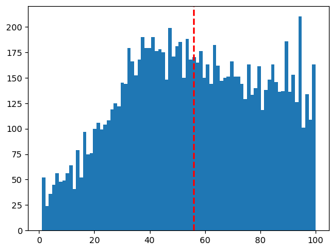

```python
max_performer_peak_pos_mean = int(max_performer_peak_pos_mean.iloc[0,0])
plt.axvline(max_performer_peak_pos_mean, color='r', linestyle='dashed', linewidth=2, label='Mean')
plt.hist(data=max_performer_peak, x='peak_pos', bins=80);
```

### Method 5 Part III: preserve the true wks_on_chart & peak_pos mean values in the raw data (includes one-hit wonder data)

### Mechanics 5 Part III: let's add a column that counts the times a performer/title were on the charts and add a columns to the df with those counts

```python
df2['woc_mean'] = df2.groupby(['performer', 'title'], as_index=False)['wks_on_chart'].transform('mean')
df2['peak_mean'] = df2.groupby(['performer', 'title'], as_index=False)['peak_pos'].transform('mean')
# # let's make new cols with the means of a couple of other cols
```

```python
grouped_df = df2.groupby(['performer', 'title']).count()
# doing a free for all group by on all of the columns without using .agg will collapse the grouped by cols into rows instead of cols
# you'll have to do a reset_index if you do that like the line below
#grouped_df = grouped_df.reset_index()
grouped_df
```

| performer | title | chart_week | current_week | last_week | peak_pos | wks_on_chart | woc_mean | peak_mean |
| --- | --- | --- | --- | --- | --- | --- | --- | --- |
| "Groove" Holmes | Misty | 11 | 11 | 10 | 11 | 11 | 11 | 11 |
|  | What Now My Love | 3 | 3 | 2 | 3 | 3 | 3 | 3 |
| "Little" Jimmy Dickens | May The Bird Of Paradise Fly Up Your Nose | 10 | 10 | 9 | 10 | 10 | 10 | 10 |
| "Pookie" Hudson | I Know I Know | 1 | 1 | 0 | 1 | 1 | 1 | 1 |
| "Weird Al" Yankovic | Amish Paradise | 16 | 16 | 15 | 16 | 16 | 16 | 16 |
| ... | ... | ... | ... | ... | ... | ... | ... | ... |
| will.i.am & Nicki Minaj | Check It Out | 15 | 15 | 13 | 15 | 15 | 15 | 15 |
| will.i.am Featuring Justin Bieber | #thatPOWER | 16 | 16 | 15 | 16 | 16 | 16 | 16 |
| will.i.am Featuring Mick Jagger & Jennifer Lopez | T.H.E (The Hardest Ever) | 8 | 8 | 6 | 8 | 8 | 8 | 8 |
| will.i.am Featuring Miley Cyrus | Fall Down | 1 | 1 | 0 | 1 | 1 | 1 | 1 |
| will.i.am Featuring Miley Cyrus, French Montana, Wiz Khalifa & DJ Mustard | Feelin' Myself | 2 | 2 | 1 | 2 | 2 | 2 | 2 |

31052 rows × 7 columns

```python
grouped_df = grouped_df.reset_index()
# this is the main command you have to do to pop the rows back into columns, but by that time, you've lost
#you're original values so this method really doesn't work in the end
```

```python
grouped_df['hit_count'] = grouped_df.groupby(['performer'], as_index=False)['performer'].transform('count')
grouped_df
```

|  | performer | title | chart_week | current_week | last_week | peak_pos | wks_on_chart | woc_mean | peak_mean | hit_count |
| --- | --- | --- | --- | --- | --- | --- | --- | --- | --- | --- |
| 0 | "Groove" Holmes | Misty | 11 | 11 | 10 | 11 | 11 | 11 | 11 | 2 |
| 1 | "Groove" Holmes | What Now My Love | 3 | 3 | 2 | 3 | 3 | 3 | 3 | 2 |
| 2 | "Little" Jimmy Dickens | May The Bird Of Paradise Fly Up Your Nose | 10 | 10 | 9 | 10 | 10 | 10 | 10 | 1 |
| 3 | "Pookie" Hudson | I Know I Know | 1 | 1 | 0 | 1 | 1 | 1 | 1 | 1 |
| 4 | "Weird Al" Yankovic | Amish Paradise | 16 | 16 | 15 | 16 | 16 | 16 | 16 | 11 |
| ... | ... | ... | ... | ... | ... | ... | ... | ... | ... | ... |
| 31047 | will.i.am & Nicki Minaj | Check It Out | 15 | 15 | 13 | 15 | 15 | 15 | 15 | 1 |
| 31048 | will.i.am Featuring Justin Bieber | #thatPOWER | 16 | 16 | 15 | 16 | 16 | 16 | 16 | 1 |
| 31049 | will.i.am Featuring Mick Jagger & Jennifer Lopez | T.H.E (The Hardest Ever) | 8 | 8 | 6 | 8 | 8 | 8 | 8 | 1 |
| 31050 | will.i.am Featuring Miley Cyrus | Fall Down | 1 | 1 | 0 | 1 | 1 | 1 | 1 | 1 |
| 31051 | will.i.am Featuring Miley Cyrus, French Montan... | Feelin' Myself | 2 | 2 | 1 | 2 | 2 | 2 | 2 | 1 |

31052 rows × 10 columns

```python
# grouped_df[grouped_df[('hit_count')] > 1]
grouped_df_noOneHits = grouped_df[grouped_df[('hit_count')] > 1]
grouped_df_noOneHits
# yes this is what i want but do it on df2 instead to not lose the peak_pos & woc means when determining the hit_count col?
```

|  | performer | title | chart_week | current_week | last_week | peak_pos | wks_on_chart | woc_mean | peak_mean | hit_count |
| --- | --- | --- | --- | --- | --- | --- | --- | --- | --- | --- |
| 0 | "Groove" Holmes | Misty | 11 | 11 | 10 | 11 | 11 | 11 | 11 | 2 |
| 1 | "Groove" Holmes | What Now My Love | 3 | 3 | 2 | 3 | 3 | 3 | 3 | 2 |
| 4 | "Weird Al" Yankovic | Amish Paradise | 16 | 16 | 15 | 16 | 16 | 16 | 16 | 11 |
| 5 | "Weird Al" Yankovic | Canadian Idiot | 3 | 3 | 2 | 3 | 3 | 3 | 3 | 11 |
| 6 | "Weird Al" Yankovic | Eat It | 12 | 12 | 11 | 12 | 12 | 12 | 12 | 11 |
| ... | ... | ... | ... | ... | ... | ... | ... | ... | ... | ... |
| 31041 | twenty one pilots | Shy Away | 1 | 1 | 0 | 1 | 1 | 1 | 1 | 11 |
| 31042 | twenty one pilots | Stressed Out | 52 | 52 | 49 | 52 | 52 | 52 | 52 | 11 |
| 31043 | twenty one pilots | Tear In My Heart | 8 | 8 | 6 | 8 | 8 | 8 | 8 | 11 |
| 31044 | will.i.am | I Got It From My Mama | 9 | 9 | 8 | 9 | 9 | 9 | 9 | 2 |
| 31045 | will.i.am | It's A New Day | 2 | 2 | 0 | 2 | 2 | 2 | 2 | 2 |

23961 rows × 10 columns

```python
grouped_df_noOneHits['woc_mean'] = grouped_df_noOneHits.groupby(['performer'], as_index=False)['wks_on_chart'].transform('mean')
grouped_df_noOneHits
# this gets new mean of non-one hit wonder song-artist combos
```

|  | performer | title | chart_week | current_week | last_week | peak_pos | wks_on_chart | woc_mean | peak_mean | hit_count |
| --- | --- | --- | --- | --- | --- | --- | --- | --- | --- | --- |
| 0 | "Groove" Holmes | Misty | 11 | 11 | 10 | 11 | 11 | 7.000000 | 11 | 2 |
| 1 | "Groove" Holmes | What Now My Love | 3 | 3 | 2 | 3 | 3 | 7.000000 | 3 | 2 |
| 4 | "Weird Al" Yankovic | Amish Paradise | 16 | 16 | 15 | 16 | 16 | 8.272727 | 16 | 11 |
| 5 | "Weird Al" Yankovic | Canadian Idiot | 3 | 3 | 2 | 3 | 3 | 8.272727 | 3 | 11 |
| 6 | "Weird Al" Yankovic | Eat It | 12 | 12 | 11 | 12 | 12 | 8.272727 | 12 | 11 |
| ... | ... | ... | ... | ... | ... | ... | ... | ... | ... | ... |
| 31041 | twenty one pilots | Shy Away | 1 | 1 | 0 | 1 | 1 | 14.454545 | 1 | 11 |
| 31042 | twenty one pilots | Stressed Out | 52 | 52 | 49 | 52 | 52 | 14.454545 | 52 | 11 |
| 31043 | twenty one pilots | Tear In My Heart | 8 | 8 | 6 | 8 | 8 | 14.454545 | 8 | 11 |
| 31044 | will.i.am | I Got It From My Mama | 9 | 9 | 8 | 9 | 9 | 5.500000 | 9 | 2 |
| 31045 | will.i.am | It's A New Day | 2 | 2 | 0 | 2 | 2 | 5.500000 | 2 | 2 |

23961 rows × 10 columns

### Method 5 Part IV: Let's deal only with data where only performers who had at least one song on the charts longer than twist and shout (26 wks)

### Mechanics 5 Part IV: create new df only with performers who had songs on charts longer than twist and shout. Now assign the mean for wks_on_chart and peak_pos to two new columns in the df, so can plot them.

```python
import numpy as np
results = np.where((max3['wks_on_chart'] > bmaxweeks), (max3['performer'], max3['title'], max3['wks_on_chart']), np.nan)
df3 = pd.DataFrame(results).transpose()
df3=df3.rename(columns={0:"Performer",1:"Title", 2:"Wks_On_Chart"})
df3 = df3.dropna()
print (df3)
```

```
            Performer                      Title Wks_On_Chart
0       Glass Animals                 Heat Waves           91
1          The Weeknd            Blinding Lights           90
2     Imagine Dragons                Radioactive           87
3          AWOLNATION                       Sail           79
4            Dua Lipa                 Levitating           77
...               ...                        ...          ...
1255           Calboy                    Envy Me           27
1256          50 Cent             Just A Lil Bit           27
1257              US3  Cantaloop (Flip Fantasia)           27
1258      Gary Wright              Love Is Alive           27
1259             P!nk                 Most Girls           27

[1260 rows x 3 columns]
```

```python
print (len(df3.index))
```

```
1260
```

```python
print ("Message 5a: The Beatles longest run of weeks on the chart in America was for \r") # + maxes2.iloc[0].wks_on_chart
print (maxes2.iloc[0].wks_on_chart) #+ print ("\r weeks")
print ("weeks")
```

```
Message 5a: The Beatles longest run of weeks on the chart in America was for
26
weeks
```

```python
print ("Message 5b: There were ")
print (len(df3.index))
print ("other bands that had songs with longer runs than that.")
```

[output not shown]

```python
maxes = df.groupby(['title'],as_index=False)['wks_on_chart'].max()
print (maxes)
```

```
                 title  wks_on_chart
0   4 - By The Beatles             5
1   A Hard Day's Night            13
2        Act Naturally             7
3      Ain't She Sweet             9
4        All My Loving             6
..                 ...           ...
61        What Goes On             2
62    Yellow Submarine             9
63           Yes It Is             4
64           Yesterday            11
65   You Can't Do That             4

[66 rows x 2 columns]
```

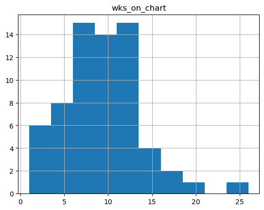

```python
# this might be a better way of showing it...
# how about a distribution histogram of max number of weeks each charting beatles song had on the chart
maxes.hist('wks_on_chart');
```

```python
# let's save this to an image
plt.savefig("billboardHist1");
```

```python
df2
```

|  | chart_week | current_week | title | performer | last_week | peak_pos | wks_on_chart | woc_mean | peak_mean |
| --- | --- | --- | --- | --- | --- | --- | --- | --- | --- |
| 0 | 2022-01-01 | 1 | All I Want For Christmas Is You | Mariah Carey | 1.0 | 1 | 50 | 33.156250 | 8.328125 |
| 1 | 2022-01-01 | 2 | Rockin' Around The Christmas Tree | Brenda Lee | 2.0 | 2 | 44 | 29.649123 | 8.578947 |
| 2 | 2022-01-01 | 3 | Jingle Bell Rock | Bobby Helms | 4.0 | 3 | 41 | 28.654545 | 16.090909 |
| 3 | 2022-01-01 | 4 | A Holly Jolly Christmas | Burl Ives | 5.0 | 4 | 25 | 20.421053 | 10.473684 |
| 4 | 2022-01-01 | 5 | Easy On Me | Adele | 3.0 | 1 | 11 | 16.000000 | 3.161290 |
| ... | ... | ... | ... | ... | ... | ... | ... | ... | ... |
| 341495 | 2021-11-13 | 96 | Lets Go Brandon | Loza Alexander | 38.0 | 38 | 3 | 2.000000 | 40.333333 |
| 341496 | 2021-11-13 | 97 | Just About Over You | Priscilla Block | 95.0 | 95 | 4 | 4.000000 | 89.571429 |
| 341497 | 2021-11-13 | 98 | To Be Loved By You | Parker McCollum | 96.0 | 96 | 2 | 10.500000 | 56.400000 |
| 341498 | 2021-11-13 | 99 | Let's Go Brandon | Bryson Gray Featuring Tyson James & Chandler C... | 28.0 | 28 | 2 | 1.500000 | 28.000000 |
| 341499 | 2021-11-13 | 100 | Ghost Town | Benson Boone | NaN | 100 | 1 | 1.000000 | 100.000000 |

341500 rows × 9 columns